Name: Alex Lundin Assignment: Project 1 # Header for project

# Data set 1 - heart disease

# Columns labeled on graph and in notes

# 5 R functions (names, str,head, cor, summary)

# 2 meaningful graphs

# –(Scatterplot Chest Pain ~ Heart Disease)

# –(Densityplot Chest Pain Type)

# Algorithims

# –Linear Regression

# – knn clustering

# Metrics

# –r squared for Linear Regression

# –predictions for knn clustering

# Analysis

# –this dataset works well with regression since it assigns a numeric value of heart disease diagnosis

# Data set 2- Poker hand

# Columns labeled on graph and in notes

# 5 R functions (names, str,head, cor, summary)

# 2 meaningful graphs

# – (Scatterplot: Card 1 value ~ Hand Classfication)

# – (pairs plot: all predictors)

# – (Density Plot: Card 1 value)

# – (Density Plot: Card 1 suit)

# Algorithims

# –Linear Regression

# –Logistic Regression

# Metrics

# –r squared for Linear Regression

# –accuracy for Logistic Regression

# Analysis

# –this data set works better with classification because it assigns each hand a class.

# –poker hands are still subject to alot of radomness that is not very predictable

# Heart disease

This data set is from the following URL: https://archive.ics.uci.edu/ml/datasets/Heart+Disease

This study pulls various pieces of data from subjects to learn about factors related to heart disease.

14 attributes of the original 76 attributes were used in the processed data sets.

Complete attribute documentation: (These are renumbered from the original website to match the trimed data) 1 age: age in years 2 sex: sex (1 = male; 0 = female) 3 cp: chest pain type – Value 1: typical angina – Value 2: atypical angina – Value 3: non-anginal pain – Value 4: asymptomatic 4 trestbps: resting blood pressure (in mm Hg on admission to the hospital) 5 chol: serum cholestoral in mg/dl 6 fbs: (fasting blood sugar > 120 mg/dl) (1 = true; 0 = false) 7 restecg: resting electrocardiographic results 8 thalach: maximum heart rate achieved 9 exang: exercise induced angina (1 = yes; 0 = no) 10 oldpeak = ST depression induced by exercise relative to rest 11 slope: the slope of the peak exercise ST segment – Value 1: upsloping – Value 2: flat – Value 3: downsloping 12 ca: number of major vessels (0-3) colored by flourosopy 13 thal: 3 = normal; 6 = fixed defect; 7 = reversable defect 14 num: diagnosis of heart disease (angiographic disease status) – Value 0: < 50% diameter narrowing – Value 1: > 50% diameter narrowing (in any major vessel: attributes 59 through 68 are vessels)

# load the project data for first set heart disease

```r
# different file locations for the project
dataPathHomeComputer <- "C:\\Users\\Alex\\Desktop\\Screen-Cleaner\\GitHub\\UTDSummer2018\\CS-4375.0U2-Machine-Learning\\Projects\\project1\\data\\processed.hungarian.data"

dataPathSchoolComputer <- "H:\\GitHub\\UTDSummer2018\\CS-4375.0U2-Machine-Learning\\Projects\\project1\\data\\processed.hungarian.data"

# create the dataframe for heart disease
df_hd <- read.table(dataPathHomeComputer)

# sets the column names of the data frame with colnames function
colnames(df_hd) <- c("age", "sex", "cp", "trestbps", "chol", "fbs", "restecg", "thalach", "exang", "oldpeak", "slope", "ca", "thal", "num")



# separate out the train and test dataframes following a similar naming convention of original frame

# Set random seed to ensure reproducibility of the shuffle.
set.seed(1958)


# shuffle the df_hd and store into a new df_hd frame
df_hd_numberOfRows <- nrow(df_hd)
shuf_df_hd <- df_hd[sample(df_hd_numberOfRows), ]

# set train_data df_hd with the train_data indices
train_data_indices <- 1:round(0.75 * df_hd_numberOfRows)
train_data <- shuf_df_hd[train_data_indices, ]
# set test_data df_hd with the test_data indices
test_data_indices <- (round(0.75 * df_hd_numberOfRows) + 1):df_hd_numberOfRows
test_data <- shuf_df_hd[test_data_indices, ]
```

# investigate the data with names, str, head, summary and cor

```r
# look at the names of the data frame
nameArray <- names(df_hd)
printString <- "The names of the columns are:"

# print a useful message with a compact version of the columns using str
print(printString)
```

```
## [1] "The names of the columns are:"
```

```r
str(nameArray)
```

```
##  chr [1:14] "age" "sex" "cp" "trestbps" "chol" "fbs" "restecg" ...
```

```r
# show first 6 instances of the frame
head(df_hd)
```

```
##   age sex cp trestbps chol fbs restecg thalach exang oldpeak slope ca thal
## 1  28   1  2      130  132   0       2     185     0       0     0  0    0
## 2  29   1  2      120  243   0       0     160     0       0     0  0    0
## 3  29   1  2      140    0   0       0     170     0       0     0  0    0
## 4  30   0  1      170  237   0       1     170     0       0     0  0    6
## 5  31   0  2      100  219   0       1     150     0       0     0  0    0
## 6  32   0  2      105  198   0       0     165     0       0     0  0    0
##   num
## 1   0
## 2   0
## 3   0
## 4   0
## 5   0
## 6   0
```

The 4 main columns that correlate highly with a diagonois of heart disease are: 3 // cp // chest pain 9 // exang // exercise induced angina 10 // oldpeak // ST depression induced by exercise relative to rest 11 // slope // slope of the peak exercise ST segment all four of these have a correlation above .5 with the diagnois of heart disease in patients.

```r
# store a summary of the data frame
sm <- summary(df_hd)

# print the summary
print(sm)
```

```
##       age             sex               cp           trestbps
##  Min.   :28.00   Min.   :0.0000   Min.   :1.000   Min.   :  0.0
##  1st Qu.:42.00   1st Qu.:0.0000   1st Qu.:2.000   1st Qu.:120.0
##  Median :49.00   Median :1.0000   Median :3.000   Median :130.0
##  Mean   :47.83   Mean   :0.7245   Mean   :2.983   Mean   :132.1
##  3rd Qu.:54.00   3rd Qu.:1.0000   3rd Qu.:4.000   3rd Qu.:140.0
##  Max.   :66.00   Max.   :1.0000   Max.   :4.000   Max.   :200.0
##       chol            fbs             restecg          thalach
##  Min.   :  0.0   Min.   :0.00000   Min.   :0.0000   Min.   :  0.0
##  1st Qu.:198.0   1st Qu.:0.00000   1st Qu.:0.0000   1st Qu.:122.0
##  Median :237.0   Median :0.00000   Median :0.0000   Median :140.0
##  Mean   :231.2   Mean   :0.06803   Mean   :0.2177   Mean   :138.7
##  3rd Qu.:277.0   3rd Qu.:0.00000   3rd Qu.:0.0000   3rd Qu.:155.0
##  Max.   :603.0   Max.   :1.00000   Max.   :2.0000   Max.   :190.0
##      exang           oldpeak           slope              ca
##  Min.   :0.0000   Min.   :0.0000   Min.   :0.0000   Min.   :0
##  1st Qu.:0.0000   1st Qu.:0.0000   1st Qu.:0.0000   1st Qu.:0
##  Median :0.0000   Median :0.0000   Median :0.0000   Median :0
##  Mean   :0.3027   Mean   :0.5861   Mean   :0.6701   Mean   :0
##  3rd Qu.:1.0000   3rd Qu.:1.0000   3rd Qu.:2.0000   3rd Qu.:0
##  Max.   :1.0000   Max.   :5.0000   Max.   :3.0000   Max.   :0
##       thal             num
##  Min.   :0.0000   Min.   :0.0000
##  1st Qu.:0.0000   1st Qu.:0.0000
##  Median :0.0000   Median :0.0000
##  Mean   :0.5374   Mean   :0.3605
##  3rd Qu.:0.0000   3rd Qu.:1.0000
##  Max.   :7.0000   Max.   :1.0000
```

```r
# coerce all predictors and targets as numeric for correlation function

xPredictor <- as.numeric(df_hd$cp)
yTarget <- as.numeric(df_hd$num)

print("Correlation of -- Chest pain and heart disease:")
```

```
## [1] "Correlation of -- Chest pain and heart disease:"
```

```r
cor(xPredictor, yTarget)
```

```
## [1] 0.505864
```

```r
xPredictor <- as.numeric(df_hd$exang)
print("Correlation of -- Exercise induced chest pain and heart disease:")
```

```
## [1] "Correlation of -- Exercise induced chest pain and heart disease:"
```

```r
cor(xPredictor, yTarget)
```

```
## [1] 0.5845414
```

```r
xPredictor <- as.numeric(df_hd$oldpeak)
print("Correlation of -- ST depression, aka irregular heart beat, due to exercise and heart disease:")
```

```
## [1] "Correlation of -- ST depression, aka irregular heart beat, due to exercise and heart disease:"
```

```r
cor(xPredictor, yTarget)
```

```
## [1] 0.5457004
```

```r
xPredictor <- as.numeric(df_hd$slope)
print("Correlation of -- Slope of ST depression during peak exercise and heart disease:")
```

```
## [1] "Correlation of -- Slope of ST depression during peak exercise and heart disease:"
```

```r
cor(xPredictor, yTarget)
```

```
## [1] 0.580153
```

# two informative graphs

The scatter plot shows the likelyhood of heart disease for each type of chest pain (which ranges from 1-4) The scatter plot function in R complains when there is a fixed number of observance values (chest pain from 1-4)

The density plots show the highest correlators do not have a normal distrubtion of occcurances in the data set. The predictors are very un normally distributed.

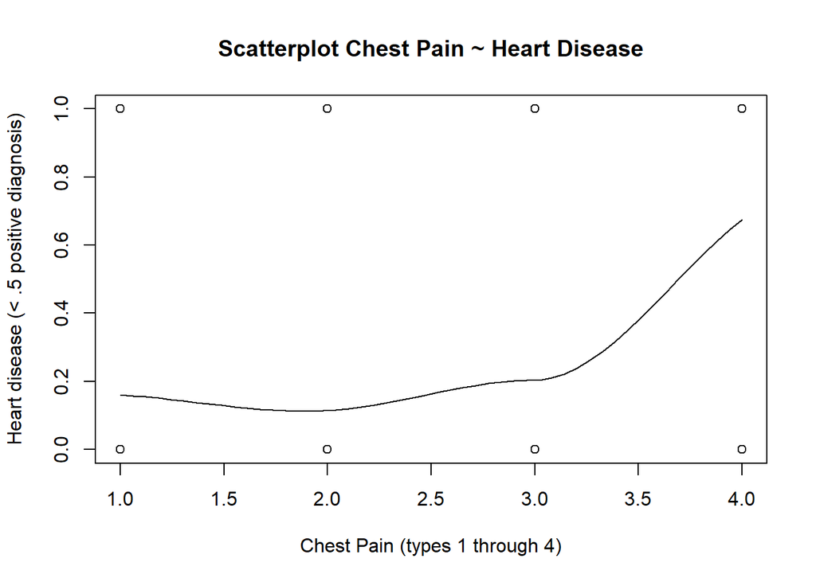

```r
# scatterplot for data view
scatter.smooth(x=df_hd$cp, y=df_hd$num, main="Scatterplot Chest Pain ~ Heart Disease", xlab="Chest Pain (types 1 through 4)", ylab="Heart disease (< .5 positive diagnosis)")
```

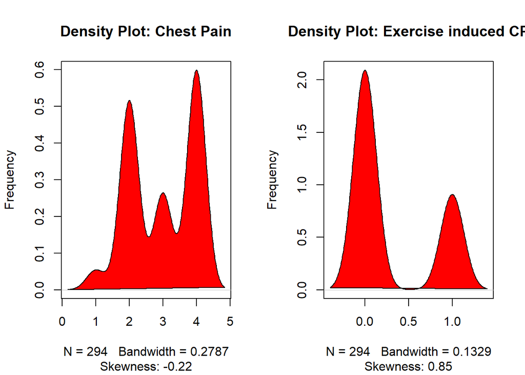

```r
# # Density plot
par(mfrow=c(1, 2))  # divide graph area in 2 columns

plot(density(df_hd$cp), main="Density Plot: Chest Pain", ylab="Frequency", sub=paste("Skewness:", round(e1071::skewness(df_hd$cp), 2)))
polygon(density(df_hd$cp), col="red")

plot(density(df_hd$exang), main="Density Plot: Exercise induced CP", ylab="Frequency", sub=paste("Skewness:", round(e1071::skewness(df_hd$exang), 2)))
polygon(density(df_hd$exang), col="red")
```